# blog_narrative_study

Carine Hajjar

11/27/2020

- narrative: Hispanics made this race a close call for Biden (at least one factor) and reaching this demographic was a huge failure for Democrats

# Notes on Pew Data

[Pew](https://www.pewresearch.org/fact-tank/2019/11/20/in-a-rising-number-of-u-s-counties-hispanic-and-black-americans-are-the-majority/) info using Census - note from Pew on data: “This analysis includes only counties with 10,000 or more residents in 2018. These counties account for 77% of the nation’s 3,142 counties and 99% of the U.S. population.” - CITATION: Pew Research Center analysis of 2000 decennial census and 2018 Census Bureau population estimates. - official name of table: “Population in U.S. counties where Hispanic, black, or indigenous people are a **large** share of residents” - column names: “percent of population that was one racial/ethnic group other than white in 2018” AND “largest racial/ethnic group, 2018” - article: by Katherine Schaeffer - 2018: 151 US counties where Hispanics, blacks, and American Indians/Alaska Natives made up majority of pop - up from 110 in 2000 - 41 of new were black or Hispanic

# Overall relationship between prop hispanic and d vote 2020

```r
county_rel <- dat %>%
ggplot(aes(one_nonwhite_group, D_pv2p))+
  geom_point() +
  geom_smooth(method = lm) +
  geom_hline(yintercept = 0.5,
             colour = "red",
             linetype = "dashed")+
  labs(title = "The Relationship Between the Percentage of the \n Hispanic Population and the 2020 Democratic Vote Share",
       subtitle = "Hispanic-Majority Counties",
       x = "Percentage of Hispanic Citizens per County",
       y= "Democratic Vote Share") +
  scale_y_continuous(labels = scales::percent) +
  scale_x_continuous(labels = scales::percent) +
  my_theme

ggsave("~/Desktop/R studio/carine-h.github.io/images/10_county_rel.png", county_rel)
```

# Plots

```r
#####-------------------------------------------------------------------------------#
##### Hist and Scatter ####
#####-------------------------------------------------------------------------------#

states <- c("Arizona", "California", "Florida", "Kansas", "New Mexico", "New York", "Texas", "Washington")

png("~/Desktop/R studio/carine-h.github.io/images/10_hist_d_change.png", width=800, height=400)
hist(dat$d_marg_change,
     main = "Hispanic-Majority County-Level Change in \nDemocratic Vote Share Margin: 2016-2020",
     col = "dodgerblue",
     xlab = "% Change in Democratic Margin of Victory")
abline(v = mean(dat$d_marg_change, na.rm = TRUE), col = 'red', lwd = 2)
dev.off()
```

```r
# all together
  # Q does this look good tho???
m1 <- plot_usmap(data = dat, regions = "counties", values = "d_marg_change",
           include = states,
           exclude = "New York") +
  scale_fill_gradient2(
    high = "blue",
    mid = "white",
    low = "red",
    breaks = c(-50,-25,0,25,50),
    limits = c(-50,50),
    name = "Win Margin") +
  theme_void()+
  labs(title = "2016-2020 Change in Democratic Win Margins",
  subtitle = "Hispanic-Majority Counties") +
  theme(plot.title = element_text(face = "bold"))

ggsave("~/Desktop/R studio/carine-h.github.io/images/10_dem_comp.png", m1)
m2 <- plot_usmap(data = dat, regions = "counties", values = "D_pv2p",
           include = states,
           exclude = "New York") +
  scale_fill_stepsn(breaks=c(dat$D_pv2p,seq(0, .50, 1)),
                    colours=c("red", "white", "blue")) +
  theme_void()+
  labs(title = "2020 Winners in Hispanic-Majority Counties",
       subtitle = "Presidential Election 2020") +
  theme(plot.title = element_text(face = "bold")) +
  theme(legend.position = "none")


ggsave("~/Desktop/R studio/carine-h.github.io/images/10_dem_win.png", m2)
#####-------------------------------------------------------------------------------#
##### USMAPS prep ####
#####-------------------------------------------------------------------------------#

# extracting just counties we want
fip_fl <- dat$fips[dat$state == "Florida"]
fip_tx <- dat$fips[dat$state == "Texas"]
fip_nm <- dat$fips[dat$state == "New Mexico"]
fip_ks <- dat$fips[dat$state == "Kansas"]
fip_az <- dat$fips[dat$state == "Arizona"]
fip_cali <- dat$fips[dat$state == "California"]
```

```r
#####-------------------------------------------------------------------------------#
##### Florida map ####
#####-------------------------------------------------------------------------------#
# FLORIDA
fl1 <- plot_usmap(data = dat, regions = "counties", values = "d_marg_change",
           include = c(fip_fl),
           labels = TRUE) +
  scale_fill_gradient2(
    high = "blue",
    mid = "white",
    low = "red",
    breaks = c(-50,-25,0,25,50),
    limits = c(-50,50),
    name = "win margin") +
  theme_void()+
  theme(legend.position = "none")

fl2 <- plot_usmap(data = dat, regions = "counties", values = "d_marg_change",
           include = "Florida") +
  scale_fill_gradient2(
    high = "blue",
    mid = "white",
    low = "red",
    breaks = c(-50,-25,0,25,50),
    limits = c(-50,50),
    name = "Win Margin") +
  theme_void()


fl_comp <- ggarrange(fl1, fl2, ncol=2)
florida_comp <- annotate_figure(fl_comp,
               top = text_grob("Florida 2016-2020: Change in Democratic \n Win Margins in Hispanic-Majority Counties", face = "bold", size = 13),
               bottom = text_grob("Source: Pew",
                                  hjust = 1, x = 0.85, face = "italic", size = 10))

ggsave("~/Desktop/R studio/carine-h.github.io/images/10_florida_comp.png", florida_comp)
```

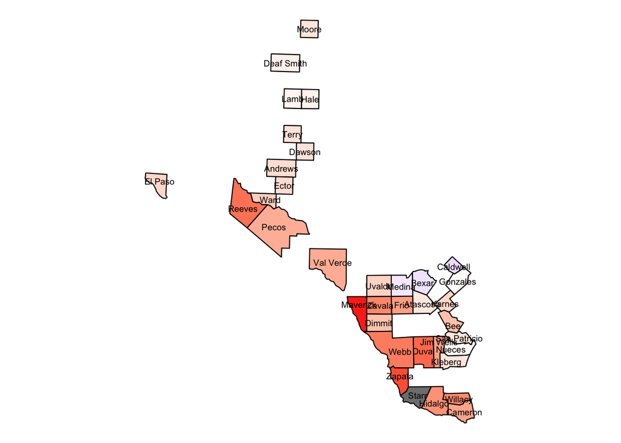

```r
#####-------------------------------------------------------------------------------#
##### Texas map ####
#####-------------------------------------------------------------------------------#
# TEXAS
p_tx <- plot_usmap(data = dat,
                   regions = "counties",
                   values = "d_marg_change",
           include = c(fip_tx),
           labels = TRUE,
           label.size = 0.1) +
  scale_fill_gradient2(
    high = "blue",
    mid = "white",
    low = "red",
    breaks = c(-50,-25,0,25,50),
    limits = c(-50,50),
    name = "win margin") +
  theme_void() +
  theme(legend.position = "none")
p_tx$layers[[2]]$aes_params$size <- 2.5
tx1 <- print(p_tx)
```

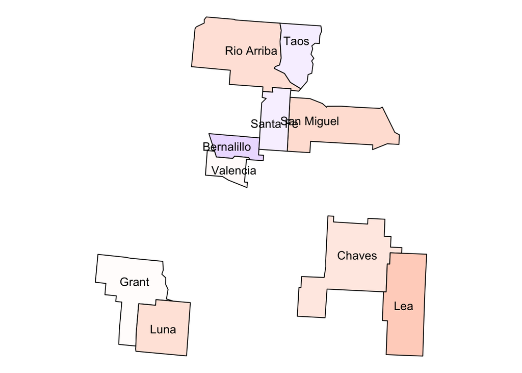

```r
tx2 <- plot_usmap(data = dat, regions = "counties", values = "d_marg_change",
           include = "Texas") +
  scale_fill_gradient2(
    high = "blue",
    mid = "white",
    low = "red",
    breaks = c(-50,-25,0,25,50),
    limits = c(-50,50),
    name = "Win Margin") +
  theme_void()


tx_comp <- ggarrange(tx1, tx2, ncol=2)
texas_comp <- annotate_figure(tx_comp,
               top = text_grob("Texas 2016-2020: Change in Democratic \n Win Margins in Hispanic-Majority Counties", face = "bold", size = 13),
               bottom = text_grob("Source: Pew",
                                  hjust = 1, x = 0.85, face = "italic", size = 10))

ggsave("~/Desktop/R studio/carine-h.github.io/images/10_texas_comp.png", texas_comp)
#####-------------------------------------------------------------------------------#
##### New Mexico map ####
#####-------------------------------------------------------------------------------#
p_nm <- plot_usmap(data = dat,
                   regions = "counties",
                   values = "d_marg_change",
           include = c(fip_nm),
           labels = TRUE) +
  scale_fill_gradient2(
    high = "blue",
    mid = "white",
    low = "red",
    breaks = c(-50,-25,0,25,50),
    limits = c(-50,50),
    name = "win margin") +
  theme_void() +
  theme(legend.position = "none")

p_nm$layers[[2]]$aes_params$size <- 4
nm1 <- print(p_nm)
```

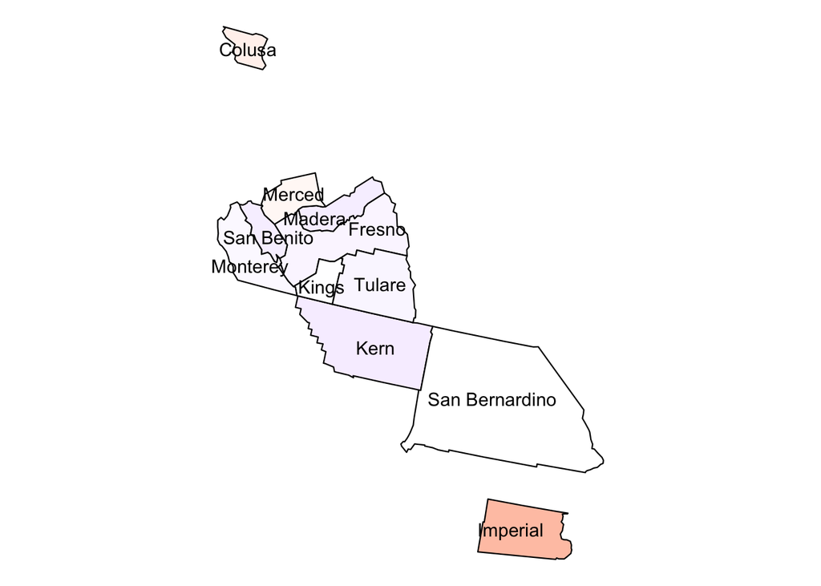

```r
nm2 <- plot_usmap(data = dat, regions = "counties", values = "d_marg_change",
           include = "New Mexico") +
  scale_fill_gradient2(
    high = "blue",
    mid = "white",
    low = "red",
    breaks = c(-50,-25,0,25,50),
    limits = c(-50,50),
    name = "Win Margin") +
  theme_void()


nm_comp <- ggarrange(nm1, nm2, ncol=2)
newmexico_comp <- annotate_figure(nm_comp,
               top = text_grob("New Mexico 2016-2020: Change in Democratic \n Win Margins in Hispanic-Majority Counties", face = "bold", size = 13),
               bottom = text_grob("Source: Pew",
                                  hjust = 1, x = 0.85, face = "italic", size = 10))

ggsave("~/Desktop/R studio/carine-h.github.io/images/10_newmexico_comp.png", newmexico_comp)
#####-------------------------------------------------------------------------------#
##### California map ####
#####-------------------------------------------------------------------------------#

p_ca <- plot_usmap(data = dat,
                   regions = "counties",
                   values = "d_marg_change",
           include = fip_cali,
           labels = TRUE) +
  scale_fill_gradient2(
    high = "blue",
    mid = "white",
    low = "red",
    breaks = c(-50,-25,0,25,50),
    limits = c(-50,50),
    name = "Win Margin") +
  theme_void() +
  theme(legend.position = "none")

p_ca$layers[[2]]$aes_params$size <- 4
ca1 <- print(p_ca)
```

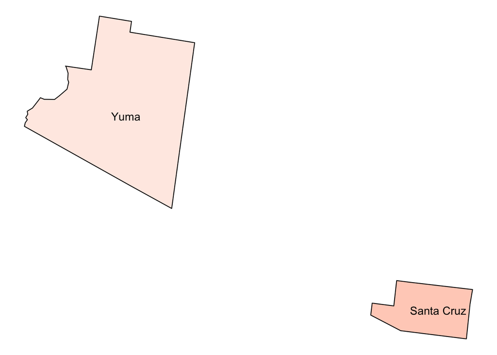

```r
ca2 <- plot_usmap(data = dat, regions = "counties", values = "d_marg_change",
           include = "California") +
  scale_fill_gradient2(
    high = "blue",
    mid = "white",
    low = "red",
    breaks = c(-50,-25,0,25,50),
    limits = c(-50,50),
    name = "Win Margin") +
  theme_void()


ca_comp <- ggarrange(ca1, ca2, ncol=2)
cali_comp <- annotate_figure(ca_comp,
               top = text_grob("California 2016-2020: Change in Democratic \n Win Margins in Hispanic-Majority Counties", face = "bold", size = 13),
               bottom = text_grob("Source: Pew",
                                  hjust = 1, x = 0.85, face = "italic", size = 10))

ggsave("~/Desktop/R studio/carine-h.github.io/images/10_cali_comp.png", cali_comp)
#####-------------------------------------------------------------------------------#
##### Arizona map ####
#####-------------------------------------------------------------------------------#

p_az <- plot_usmap(data = dat,
                   regions = "counties",
                   values = "d_marg_change",
           include = fip_az,
           labels = TRUE) +
  scale_fill_gradient2(
    high = "blue",
    mid = "white",
    low = "red",
    breaks = c(-50,-25,0,25,50),
    limits = c(-50,50),
    name = "Win Margin") +
  theme_void() +
  theme(legend.position = "none")

p_az$layers[[2]]$aes_params$size <- 4
az1 <- print(p_az)
```

```r
az2 <- plot_usmap(data = dat, regions = "counties", values = "d_marg_change",
           include = "Arizona") +
  scale_fill_gradient2(
    high = "blue",
    mid = "white",
    low = "red",
    breaks = c(-50,-25,0,25,50),
    limits = c(-50,50),
    name = "Win Margin") +
  theme_void()


az_comp <- ggarrange(az1, az2, ncol=2)
arizona_comp <- annotate_figure(az_comp,
               top = text_grob("Arizona 2016-2020: Change in Democratic \n Win Margins in Hispanic-Majority Counties", face = "bold", size = 13),
               bottom = text_grob("Source: Pew",
                                  hjust = 1, x = 0.85, face = "italic", size = 10))

ggsave("~/Desktop/R studio/carine-h.github.io/images/10_arizona_comp.png", arizona_comp)
```

Arizona, like Florida, had blue counties (that remained blue) lose part of their vote share to Trump in 2020.

# Reason 1: Rhetoric

- Trump’s rhetoric resonated better among Hispanic voters, especially in Florida

```r
#####-------------------------------------------------------------------------------#
##### Trump vs. Biden campaign speeches with General Hispanic messaging ####
#####-------------------------------------------------------------------------------#

#### General overview of buzz words ####

## pre-process: make a `quanteda` corpus from dataframe
speech_corpus <- corpus(speech_df, text_field = "text", docid_field = "url")

## pre-process: tokenize, clean, select n-grams
speech_toks_hispanic <- tokens(speech_corpus,
    remove_punct = TRUE,
    remove_symbols = TRUE,
    remove_numbers = TRUE,
    remove_url = TRUE) %>%
    tokens_tolower() %>%
    tokens_remove(pattern=c("joe","biden","donald","trump","president","kamala","harris")) %>%
    tokens_remove(pattern=stopwords("en")) %>%
    tokens_select(min_nchar=3) %>%
    tokens_ngrams(n=2, concatenator = " ") %>%
    tokens_select(pattern = c("hisp*", "communism", "latin*", "socialism", "dict*", "cuba*", "maduro",
                              "castro*"), padding = TRUE)

print(speech_toks_hispanic)
```

```
## Tokens consisting of 285 documents and 4 docvars.
## https://www.rev.com/blog/transcripts/joe-biden-meets-with-frontline-health-care-workers-transcript-november-18 :
##  [1] "" "" "" "" "" "" "" "" "" "" "" ""
## [ ... and 3,528 more ]
##
## https://www.rev.com/blog/transcripts/joe-biden-speech-on-economic-recovery-plan-transcript-november-16 :
##  [1] "" "" "" "" "" "" "" "" "" "" "" ""
## [ ... and 2,289 more ]
##
## https://www.rev.com/blog/transcripts/joe-biden-press-conference-on-affordable-care-act-transcript-november-10 :
##  [1] "" "" "" "" "" "" "" "" "" "" "" ""
## [ ... and 1,616 more ]
##
## https://www.rev.com/blog/transcripts/joe-biden-covid-19-briefing-transcript-november-9-urges-americans-to-wear-masks :
##  [1] "" "" "" "" "" "" "" "" "" "" "" ""
## [ ... and 745 more ]
##
## https://www.rev.com/blog/transcripts/joe-biden-kamala-harris-address-nation-after-victory-speech-transcript-november-7 :
##  [1] "" "" "" "" "" "" "" "" "" "" "" ""
## [ ... and 1,298 more ]
##
## https://www.rev.com/blog/transcripts/joe-biden-november-6-speech-transcript-were-going-to-win-this-race :
##  [1] "" "" "" "" "" "" "" "" "" "" "" ""
## [ ... and 502 more ]
##
## [ reached max_ndoc ... 279 more documents ]
```

```r
## pre-process: make doc-freq matrix
speech_dfm_hispanic <- dfm(speech_toks_hispanic, groups = "candidate")

## summarise and visualise
tstat_freq_hispanic <- textstat_frequency(speech_dfm_hispanic)
head(tstat_freq_hispanic, 100)
```

```
##                            feature frequency rank docfreq group
## 1                                     774491    1       2   all
## 2               hispanic americans        37    2       2   all
## 3                hispanic american        32    3       2   all
## 4                 latino community        30    4       2   all
## 5               hispanic community        16    5       2   all
## 6                     latino asian        12    6       1   all
## 7               latino communities        12    6       2   all
## 8                    latin america        11    8       2   all
## 9             hispanic communities        11    8       2   all
## 10                  cuba nicaragua        10   10       2   all
## 11                   latino native         9   11       1   all
## 12                    cuban people         8   12       2   all
## 13                 latino families         7   13       1   all
## 14                   latinos three         6   14       1   all
```

[output cut: 86 more lines]

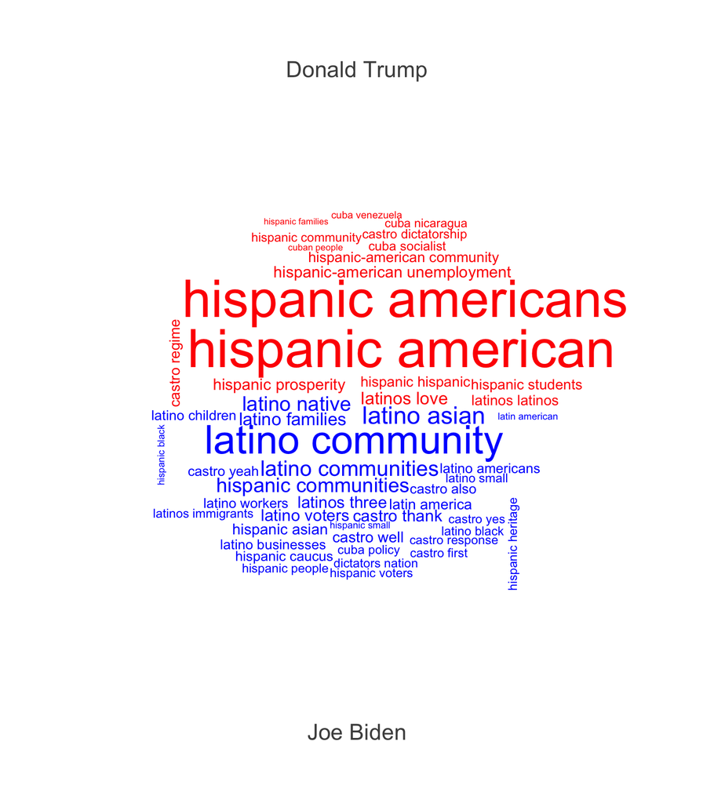

```r
textplot_wordcloud(speech_dfm_hispanic, color = c("red", "blue"), comparison = T)
```

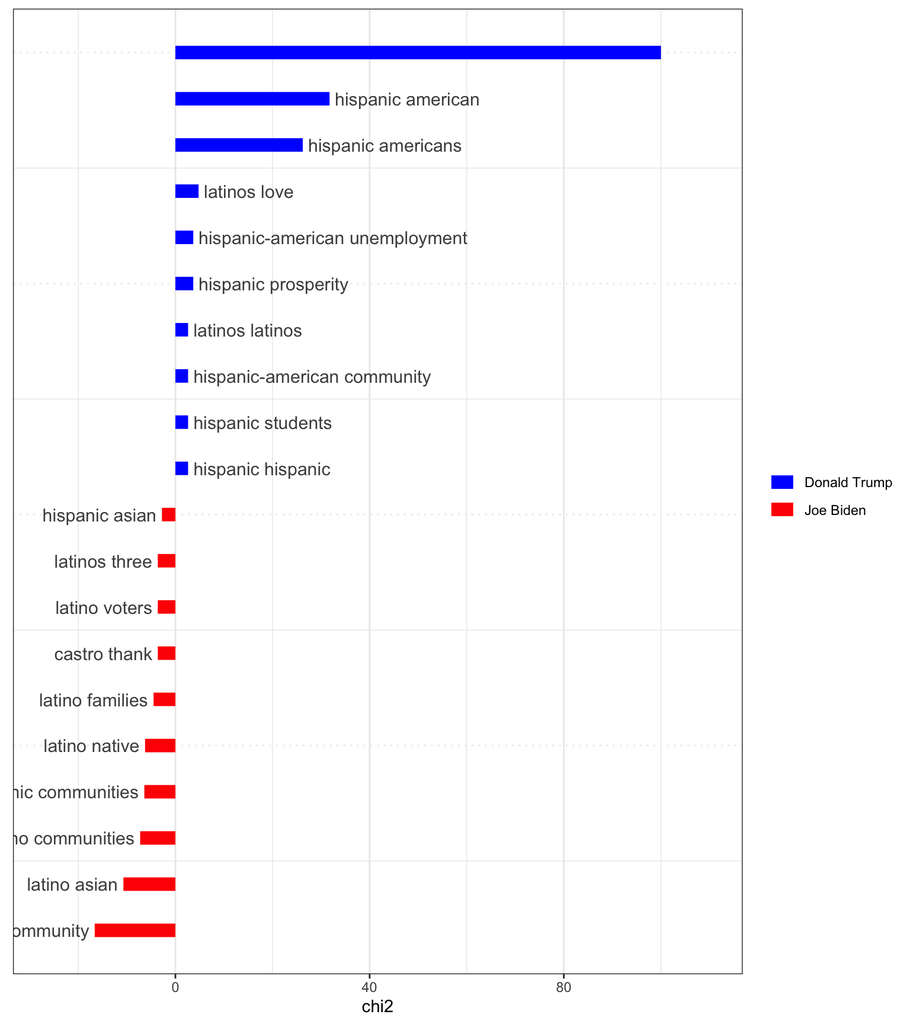

```r
trump_keyness_hispanic <- textstat_keyness(speech_dfm_hispanic, target = "Donald Trump")
textplot_keyness(trump_keyness_hispanic,
                 color = c("blue", "red"),
                 n = 10)
```

```r
#####-------------------------------------------------------------------------------#
##### Trump vs. Biden campaign speeches on cuba/venezula/nicaragua ####
#####-------------------------------------------------------------------------------#


## pre-process: make a `quanteda` corpus from dataframe
speech_corpus <- corpus(speech_df, text_field = "text", docid_field = "url")

## pre-process: tokenize, clean, select n-grams
speech_toks_comm <- tokens(speech_corpus,
    remove_punct = TRUE,
    remove_symbols = TRUE,
    remove_numbers = TRUE,
    remove_url = TRUE) %>%
    tokens_tolower() %>%
    tokens_remove(pattern=c("joe","biden","donald","trump","president","kamala","harris")) %>%
    tokens_remove(pattern=stopwords("en")) %>%
    tokens_select(min_nchar=3) %>%
    tokens_ngrams(n=2, concatenator = " ") %>%
    tokens_select(pattern = c("maduro*", "castro*", "cuba*", "venezuel*", "nicarag*"))

print(speech_toks_comm)
```

```
## Tokens consisting of 285 documents and 4 docvars.
## https://www.rev.com/blog/transcripts/joe-biden-meets-with-frontline-health-care-workers-transcript-november-18 :
## character(0)
##
## https://www.rev.com/blog/transcripts/joe-biden-speech-on-economic-recovery-plan-transcript-november-16 :
## character(0)
##
## https://www.rev.com/blog/transcripts/joe-biden-press-conference-on-affordable-care-act-transcript-november-10 :
## character(0)
##
## https://www.rev.com/blog/transcripts/joe-biden-covid-19-briefing-transcript-november-9-urges-americans-to-wear-masks :
## character(0)
##
## https://www.rev.com/blog/transcripts/joe-biden-kamala-harris-address-nation-after-victory-speech-transcript-november-7 :
## character(0)
##
## https://www.rev.com/blog/transcripts/joe-biden-november-6-speech-transcript-were-going-to-win-this-race :
## character(0)
##
## [ reached max_ndoc ... 279 more documents ]
```

```r
## pre-process: make doc-freq matrix
speech_dfm_comm <- dfm(speech_toks_comm, groups = "candidate")

## summarise and visualise
tstat_freq_comm <- textstat_frequency(speech_dfm_comm)
head(tstat_freq_comm, 100)
```

```
##                           feature frequency rank docfreq group
## 1                  cuba nicaragua        10    1       2   all
## 2                    cuban people         8    2       2   all
## 3             nicaragua venezuela         7    3       1   all
## 4                   castro regime         6    4       2   all
## 5               venezuelan people         6    4       2   all
## 6                    castro thank         6    4       1   all
## 7                     castro well         5    7       1   all
## 8             venezuela righteous         5    7       1   all
## 9                     castro also         4    9       1   all
## 10                    castro yeah         4    9       1   all
## 11                    cuba policy         3   11       1   all
## 12               venezuela people         3   11       2   all
## 13                 cuba venezuela         3   11       2   all
## 14                castro response         3   11       1   all
```

[output cut: 86 more lines]

```r
png("~/Desktop/R studio/carine-h.github.io/images/10_castro_wc.png", width=800, height=400)
textplot_wordcloud(speech_dfm_comm, color = c("red", "blue"), comparison = T)
dev.off()
```

```r
trump_keyness_comm <- textstat_keyness(speech_dfm_comm, target = "Donald Trump")
png("~/Desktop/R studio/carine-h.github.io/images/10_castro_plot.png", width=800, height=400)
textplot_keyness(trump_keyness_comm,
                 color = c("red", "blue"),
                 margin = 0.4)
dev.off()
```

```r
# this was too broad I think
# c("communis*", "sociali*","cuba*", "maduro",
#                              "castro*", "venezuela*", "chavez", "chavi*"), padding = TRUE)



#####-------------------------------------------------------------------------------#
##### Trump vs. Biden campaign speeches on socialism/communism ####
#####-------------------------------------------------------------------------------#

speech_corpus <- corpus(speech_df, text_field = "text", docid_field = "url")

## pre-process: tokenize, clean, select n-grams
speech_toks_soc <- tokens(speech_corpus,
    remove_punct = TRUE,
    remove_symbols = TRUE,
    remove_numbers = TRUE,
    remove_url = TRUE) %>%
    tokens_tolower() %>%
    tokens_remove(pattern=c("joe","biden","donald","trump","president","kamala","harris")) %>%
    tokens_remove(pattern=stopwords("en")) %>%
    tokens_select(min_nchar=3) %>%
    tokens_ngrams(n=2, concatenator = " ") %>%
    tokens_select(pattern = c("sociali*", "communis*"))

print(speech_toks_soc)
```

```
## Tokens consisting of 285 documents and 4 docvars.
## https://www.rev.com/blog/transcripts/joe-biden-meets-with-frontline-health-care-workers-transcript-november-18 :
## character(0)
##
## https://www.rev.com/blog/transcripts/joe-biden-speech-on-economic-recovery-plan-transcript-november-16 :
## character(0)
##
## https://www.rev.com/blog/transcripts/joe-biden-press-conference-on-affordable-care-act-transcript-november-10 :
## character(0)
##
## https://www.rev.com/blog/transcripts/joe-biden-covid-19-briefing-transcript-november-9-urges-americans-to-wear-masks :
## character(0)
##
## https://www.rev.com/blog/transcripts/joe-biden-kamala-harris-address-nation-after-victory-speech-transcript-november-7 :
## character(0)
##
## https://www.rev.com/blog/transcripts/joe-biden-november-6-speech-transcript-were-going-to-win-this-race :
## character(0)
##
## [ reached max_ndoc ... 279 more documents ]
```

```r
## pre-process: make doc-freq matrix
speech_dfm_soc <- dfm(speech_toks_soc, groups = "candidate")

## summarise and visualise
tstat_freq_soc  <- textstat_frequency(speech_dfm_soc)
head(tstat_freq_soc, 100)
```

```
##                           feature frequency rank docfreq group
## 1             socialized medicine        20    1       2   all
## 2                  communism made        20    1       1   all
## 3               socialist country        19    3       2   all
## 4                 communist party        11    4       2   all
## 5             socialists marxists         9    5       1   all
## 6                socialist nation         8    6       1   all
## 7              socialists elected         8    6       1   all
## 8             socialist nightmare         7    8       1   all
## 9              socialist takeover         6    9       1   all
## 10           socialist healthcare         6    9       1   all
## 11            socialist communist         5   11       1   all
## 12          socialists communists         4   12       1   all
## 13                 socialist left         4   12       1   all
## 14            socialism communism         3   14       2   all
```

[output cut: 86 more lines]

```r
png("~/Desktop/R studio/carine-h.github.io/images/10_socialist_wc.png", width=800, height=400)
textplot_wordcloud(speech_dfm_soc, color = c("red", "blue"), comparison = T, remove_punct = TRUE)
```

[output not shown]

```r
dev.off()
```

```r
trump_keyness_soc <- textstat_keyness(speech_dfm_soc, target = "Donald Trump")
png("~/Desktop/R studio/carine-h.github.io/images/10_socialist_plot.png", width=800, height=400)
textplot_keyness(trump_keyness_soc,
                 color = c("red", "blue"),
                 margin = 0.4)
dev.off()
```

```r
#####-------------------------------------------------------------------------------#
##### Trump vs. Biden campaign speeches on border ####
#####-------------------------------------------------------------------------------#

speech_corpus <- corpus(speech_df, text_field = "text", docid_field = "url")

## pre-process: tokenize, clean, select n-grams
speech_toks_border <- tokens(speech_corpus,
    remove_punct = TRUE,
    remove_symbols = TRUE,
    remove_numbers = TRUE,
    remove_url = TRUE) %>%
    tokens_tolower() %>%
    tokens_remove(pattern=c("joe","biden","donald","trump","president","kamala","harris")) %>%
    tokens_remove(pattern=stopwords("en")) %>%
    tokens_select(min_nchar=3) %>%
    tokens_ngrams(n=2, concatenator = " ") %>%
    tokens_select(pattern = c("border*", "gang*", "wall", "immigra*", "border violence", "gang violence"))

print(speech_toks_border)
```

```
## Tokens consisting of 285 documents and 4 docvars.
## https://www.rev.com/blog/transcripts/joe-biden-meets-with-frontline-health-care-workers-transcript-november-18 :
## [1] "borders right" "border going"
##
## https://www.rev.com/blog/transcripts/joe-biden-speech-on-economic-recovery-plan-transcript-november-16 :
## character(0)
##
## https://www.rev.com/blog/transcripts/joe-biden-press-conference-on-affordable-care-act-transcript-november-10 :
## character(0)
##
## https://www.rev.com/blog/transcripts/joe-biden-covid-19-briefing-transcript-november-9-urges-americans-to-wear-masks :
## character(0)
##
## https://www.rev.com/blog/transcripts/joe-biden-kamala-harris-address-nation-after-victory-speech-transcript-november-7 :
## [1] "immigrants ever"
##
## https://www.rev.com/blog/transcripts/joe-biden-november-6-speech-transcript-were-going-to-win-this-race :
## character(0)
##
## [ reached max_ndoc ... 279 more documents ]
```

```r
## pre-process: make doc-freq matrix
speech_dfm_border <- dfm(speech_toks_border, groups = "candidate")

## summarise and visualise
tstat_freq_border <- textstat_frequency(speech_dfm_border)
head(tstat_freq_border, 100)
```

```
##                     feature frequency rank docfreq group
## 1             border patrol        35    1       2   all
## 2        immigration reform        31    2       1   all
## 3       borders sacrificing        21    3       1   all
## 4        immigration system        14    4       2   all
## 5              borders want        13    5       1   all
## 6               border wall        12    6       2   all
## 7          immigration bill        11    7       1   all
## 8               borders now        11    7       1   all
## 9           borders country        11    7       1   all
## 10             gang members        11    7       1   all
## 11       immigration status         9   11       1   all
## 12              border ever         9   11       2   all
## 13         immigration plan         9   11       2   all
## 14               border u.s         9   11       1   all
```

[output cut: 86 more lines]

```r
png("~/Desktop/R studio/carine-h.github.io/images/10_border_wc.png", width=800, height=400)
textplot_wordcloud(speech_dfm_border, color = c("red", "blue"), comparison = T, remove_punct = TRUE)
```

[output not shown]

[output cut: 127 more lines]

[output not shown]

```r
dev.off()
```

```r
trump_keyness_border <- textstat_keyness(speech_dfm_border, target = "Donald Trump")
png("~/Desktop/R studio/carine-h.github.io/images/10_border_plot.png", width=800, height=400)
textplot_keyness(trump_keyness_border,
                 color = c("red", "blue"),
                 margin = 0.5)
dev.off()
```

# Reason 2: Ad Spending

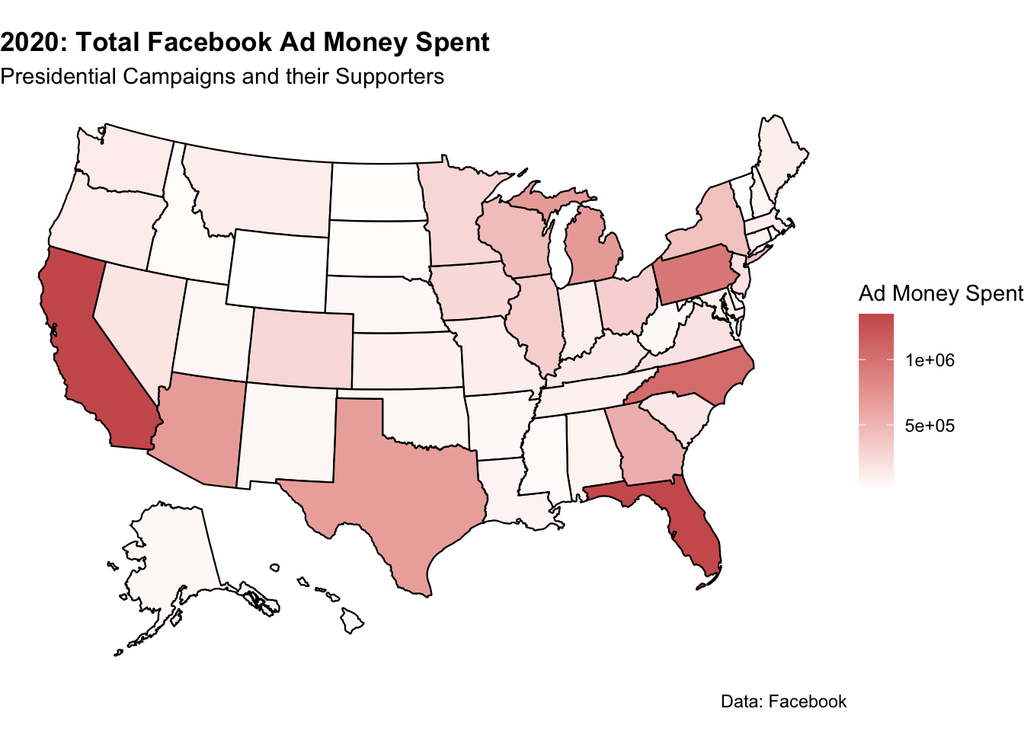

```r
# cleaning and joining FB data
fb_loc <- fb_location_df %>%
  rename("state" = "Location Name",
         "spent" = "Amount Spent (USD)") %>%
  mutate(state = state.abb[match(state,state.name)]) %>%
  na.omit()
 fb_loc <- fb_loc %>%
   mutate(ad_spent = as.numeric(fb_loc$spent))

# plotting amount spent per state on FB ads
plot_usmap(data = fb_loc, regions = "state", values = "ad_spent") +
  scale_fill_gradient2(
    high = "indianred",
    mid = "white",
    low = "grey",
    name = "Ad Money Spent")+
    theme_void()+
  labs(title = "2020: Total Facebook Ad Money Spent",
       subtitle = "Presidential Campaigns and their Supporters",
       caption = "Data: Facebook") +
  theme(plot.title = element_text(face = "bold"))
```

```r
ggsave("~/Desktop/R studio/carine-h.github.io/images/10_fb_spending.png", height = 5, width =10)
```

# TV ad spending per media market

```r
state_ad <- media_mkt_df %>%
  rename(state = "Market State",
         market = "Media Market",
         total_airings = "Total Airings 9Apr20 to 11Oct20",
         cost = "Est. Cost 9Apr20 to 11Oct29",
         biden_airings = "Pro-Biden Airings 9Apr20 to 11Oct20",
         trump_airings = "Pro-Trump Airings 9Apr20 to 11Oct20",
         biden_adv = "Biden Ad Adv 28Sept20 to 11Oct20") %>%
  select(state, market, biden_airings, trump_airings, biden_adv) %>%
  filter(state %in% c("TX", "AZ", "KS", "WA", "CA", "FL", "NM"))

state_sums <- state_ad %>%
  group_by(state) %>%
  summarise(total_ad_t = sum(trump_airings),
            total_ad_b = sum(biden_airings)) %>%
  rename(Biden = "total_ad_b",
         Trump = "total_ad_t") %>%
  gather(candidate, tot_ad, Trump:Biden) %>%
  mutate(log_ad = log(tot_ad))
```

```r
spend_tv <- ggplot(state_sums, aes(x = state, y = log_ad)) +
    geom_bar(aes(fill = candidate), stat = "identity", position = "dodge") +
    scale_fill_manual(values = c("blue", "red")) +
  labs(fill = "Candidate",
       title = "2020 Presidential Election: Log TV Ad Airings Per State",
       subtitle = "April 9th - October 20th",
       x = "State",
       y = "Log Ad Airings",
       caption = "Source: Wesleyan Media Project") +
  my_theme



ggsave("~/Desktop/R studio/carine-h.github.io/images/10_TV_spending.png", spend_tv, height = 5, width = 10)
```

https://regionalspending.web.app/spending

# Google

https://support.google.com/trends/answer/4355212?hl=en

# Section

testing

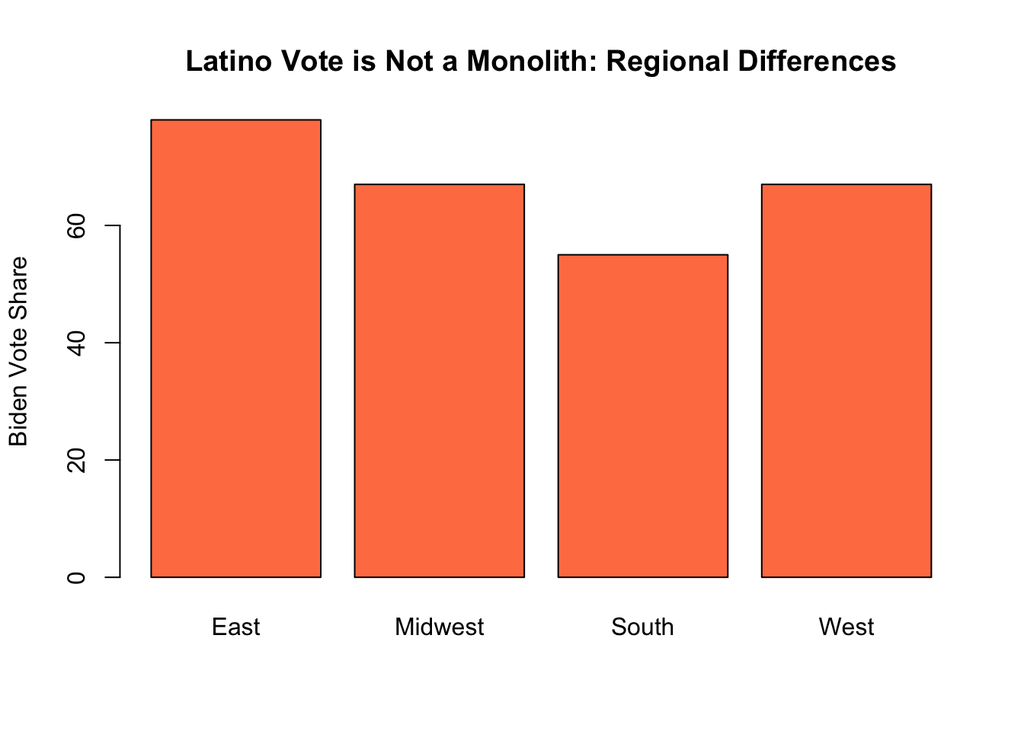

```r
region <- c("East", "Midwest", "South", "West")
biden_vs <- c(78, 67, 55, 67)
df1 <- data.frame(region, biden_vs)
barplot(df1$biden_vs, names = c("East", "Midwest", "South", "West"), ylab = "Biden Vote Share", main = "Latino Vote is Not a Monolith: Regional Differences", col = "coral")
```

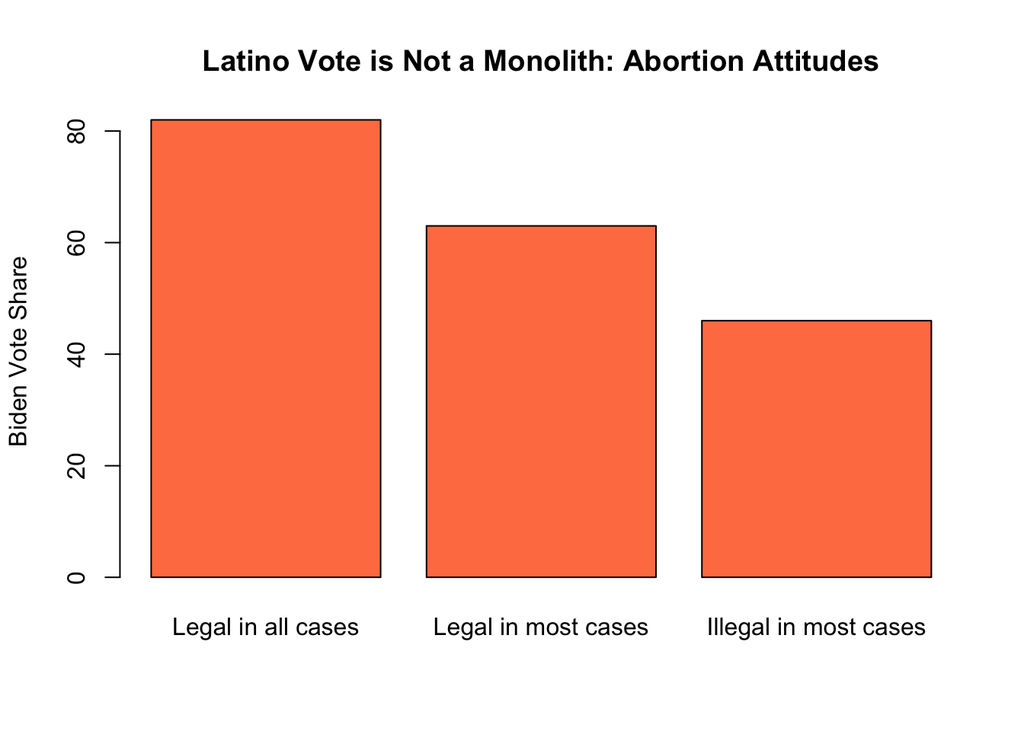

```r
name_ab <- c("Legal in all cases", "Legal in most cases", "Illegal in most cases")
biden_vs_ab <- c(82, 63, 46)
df2 <- data.frame(name_ab, biden_vs_ab)
barplot(df2$biden_vs_ab, names = name_ab, ylab = "Biden Vote Share", main = "Latino Vote is Not a Monolith: Abortion Attitudes", col = "coral")
```